# Dream Team Assignment2

Benjamin Siglow, Ethan Gruis, Shiv Patel

11/13/2020

### Spotify Stats Project

##### Ben Siglow, Ethan Gruis, Shiv Patel

### 1) An explanation of your data source (where you got it, why it is interesting, etc.) – you do not need to print your data within this document

- **Answer:** Our dataset is the Spotify dataset that can be found on Kaggle. It is interesting because it contains lots of different statistics on music that one normally wouldn’t have access to. Including attributes like popularity, tone and more are great attributes to review in this asignment.

```r
library(data.table)
library(tidyverse)
# getwd()
# setwd("C://Users//Ben Siglow//Documents//Courses//Bonus code//SpotifyAsvStat")
data <-  read_csv('https://raw.githubusercontent.com/bsiglow/SpotifyAdvStat/master/data.csv')
artist <-  read_csv('https://raw.githubusercontent.com/bsiglow/SpotifyAdvStat/master/data_by_artist.csv')
genres <- read_csv('https://raw.githubusercontent.com/bsiglow/SpotifyAdvStat/master/data_by_genres.csv')
year <- read_csv('https://raw.githubusercontent.com/bsiglow/SpotifyAdvStat/master/data_by_year.csv')
plug <-  read_csv('https://raw.githubusercontent.com/bsiglow/SpotifyAdvStat/master/data_w_genres.csv')
```

### 2) Your Questions / Hypotheses

### Hypothesis

- H_1: Loudness and duration are much better at explaining variance in popularity in punk music as compared to non-punk music.
- H_0: Loudness and duration are not better at explaining variance in popularity in punk music as compared to non-punk music
- Additionally, one major question we have is if the average profile for a punk genre is significantly different than the average profile of every other genre.
- We are discussing this question at the end because we were concerned this data analysis would affect our hypothesis decisions

### Initial Exploration & Wrangling

### Create Punk and Not Punk DataFrames

```r
punk <- genres %>%
  filter(str_detect(genres, "punk"))

not_punk <- genres %>%
  filter(!str_detect(genres, "punk"))
```

```r
head(punk)
```

```
## # A tibble: 6 x 14
##   genres acousticness danceability duration_ms energy instrumentalness liveness
##   <chr>         <dbl>        <dbl>       <dbl>  <dbl>            <dbl>    <dbl>
## 1 acous…       0.374         0.528     192338.  0.614          0.0681     0.180
## 2 anarc…       0.0531        0.316     197361.  0.875          0.00930    0.265
## 3 argen…       0.008         0.641     234610.  0.582          0.00719    0.287
## 4 art p…       0.167         0.556     220461.  0.712          0.198      0.203
## 5 austr…       0.207         0.418     213761.  0.779          0.357      0.170
## 6 austr…       0.0190        0.429     271304.  0.566          0.312      0.235
## # … with 7 more variables: loudness <dbl>, speechiness <dbl>, tempo <dbl>,
## #   valence <dbl>, popularity <dbl>, key <dbl>, mode <dbl>
```

```r
head(not_punk)
```

```
## # A tibble: 6 x 14
##   genres acousticness danceability duration_ms energy instrumentalness liveness
##   <chr>         <dbl>        <dbl>       <dbl>  <dbl>            <dbl>    <dbl>
## 1 432hz         0.495        0.299    1048887.  0.451          0.478      0.131
## 2 []            0.679        0.521     229853.  0.402          0.197      0.222
## 3 a cap…        0.622        0.577     193652.  0.346          0.00380    0.127
## 4 abstr…        0.359        0.460     343018.  0.487          0.791      0.119
## 5 abstr…        0.353        0.694     233824.  0.613          0.349      0.102
## 6 abstr…        0.206        0.723     249095.  0.645          0.00285    0.168
## # … with 7 more variables: loudness <dbl>, speechiness <dbl>, tempo <dbl>,
## #   valence <dbl>, popularity <dbl>, key <dbl>, mode <dbl>
```

- Creating a new column specifically for minute duration. This will be needed for use in later models to allow a closer range in attributes.

```r
genres$duration_min <- genres$duration_ms * (1.667 * 10^(-5))
```

- Creating the average attribute data frame for punk to be used in creating the bar chart showing the Punk song attribute breakdown.

```r
# Create punk averages dataframe
punk_avg <- data.frame(
  accousticness = mean(punk$acousticness),
  danceability = mean(punk$danceability),
  duration = mean(punk$duration_ms),
  energy = mean(punk$energy),
  instrumentalness = mean(punk$instrumentalness),
  liveness = mean(punk$liveness),
  loudness = mean(punk$loudness),
  speechiness = mean(punk$speechiness),
  tempo = mean(punk$tempo),
  valence = mean(punk$valence),
  popularity = mean(punk$popularity))
```

- Creating the average attribute data frame for not-punk to be used in creating the bar chart showing the non-Punk song attribute breakdown.

```r
# Create not-punk averages dataframe
not_punk_avg <- data.frame(
  accousticness = mean(not_punk$acousticness),
  danceability = mean(not_punk$danceability),
  duration = mean(not_punk$duration_ms),
  energy = mean(not_punk$energy),
  instrumentalness = mean(not_punk$instrumentalness),
  liveness = mean(not_punk$liveness),
  loudness = mean(not_punk$loudness),
  speechiness = mean(not_punk$speechiness),
  tempo = mean(not_punk$tempo),
  valence = mean(not_punk$valence),
  popularity = mean(not_punk$popularity))
head(not_punk_avg)
```

```
##   accousticness danceability duration    energy instrumentalness  liveness
## 1     0.4072644    0.5382789 250414.9 0.5579894        0.2013436 0.1928736
##   loudness speechiness    tempo   valence popularity
## 1 -10.4688  0.08376095 118.4533 0.4980144   40.10126
```

##### Convert Duration

- Converting the time duration for individual data frames.

```r
# Is this still necessary?
punk$duration <- punk$duration_ms * (1.667 * 10^(-5))
not_punk$duration <- not_punk$duration_ms * (1.667 * 10^(-5))

punk_avg$duration <- punk_avg$duration * (1.667 * 10^(-5))
not_punk_avg$duration <- not_punk_avg$duration * (1.667 * 10^(-5))
```

#### Gathering Average DFs

- Gathering for later plots

```r
punk_avg <- gather(punk_avg, key = Attribute, value = Average, na.rm = FALSE,
  convert = FALSE, factor_key = FALSE)
punk_avg
```

```
##           Attribute      Average
## 1     accousticness   0.11967928
## 2      danceability   0.47783469
## 3          duration   3.57168224
## 4            energy   0.79334036
## 5  instrumentalness   0.15507482
## 6          liveness   0.22764768
## 7          loudness  -7.23813396
## 8       speechiness   0.08324878
## 9             tempo 132.30064321
## 10          valence   0.54281755
## 11       popularity  40.72580556
```

```r
not_punk_avg <- gather(not_punk_avg, key = Attribute, value = Average, na.rm = F, convert = F, factor_key = F)
not_punk_avg
```

```
##           Attribute      Average
## 1     accousticness   0.40726437
## 2      danceability   0.53827891
## 3          duration   4.17441676
## 4            energy   0.55798942
## 5  instrumentalness   0.20134355
## 6          liveness   0.19287356
## 7          loudness -10.46880177
## 8       speechiness   0.08376095
## 9             tempo 118.45327091
## 10          valence   0.49801436
## 11       popularity  40.10126187
```

## Visuals

#### Distribution of popularity

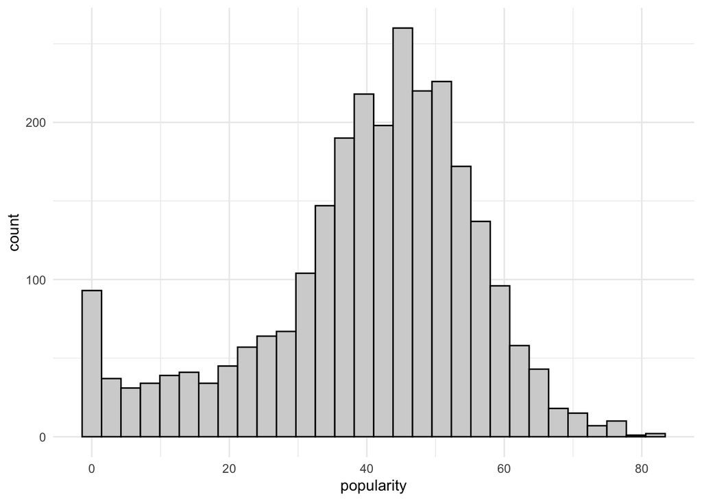

```r
library(ggplot2)
popDist <- ggplot(data = genres, aes(x = popularity)) +
  geom_histogram(fill = 'lightGrey', color = 'black') +
  theme_minimal()
popDist
```

- This distribution looks pretty good, relatively normal except for the tale at 0 (most likely caused by people not listening to certain music e.g. Pop Punk Italiano)

### Overall Loudness v. Popularity

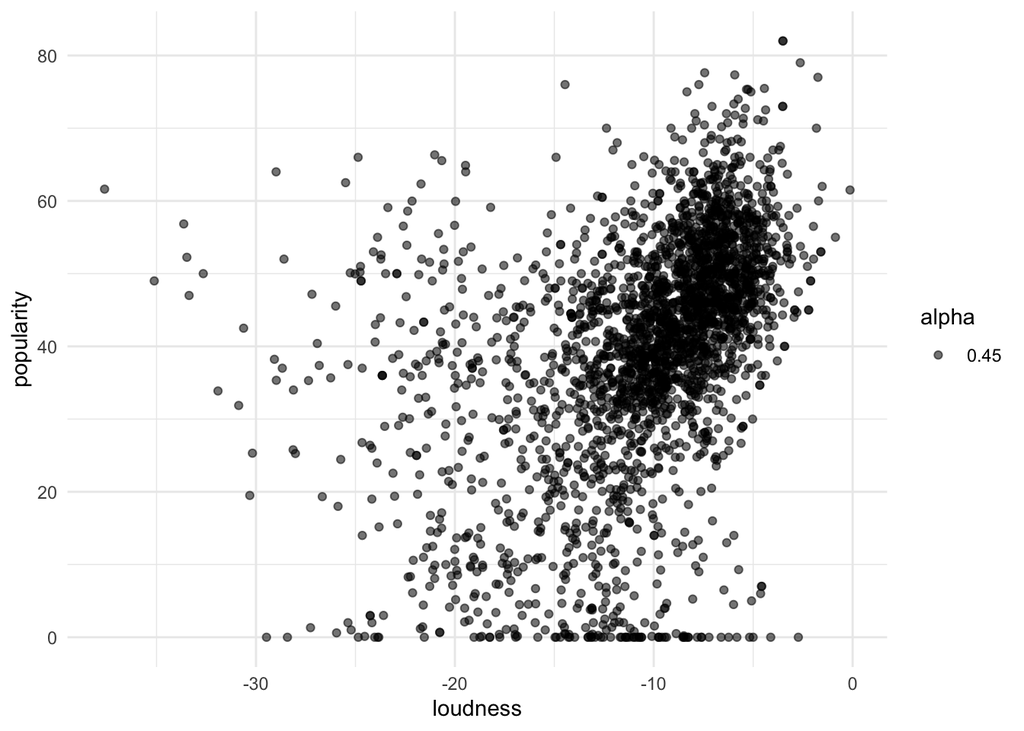

```r
loudVpop <- ggplot(data = genres, aes(x = loudness, y = popularity, alpha = .45)) +
  geom_point() +
  theme_minimal()

loudVpop
```

- This graph seems kinda off at first glance given the x-axis, but it is still a slight positive relationship between loudness and popularity. Meaning that as loudness increases, popularity increases.

### Duration v. Popularity

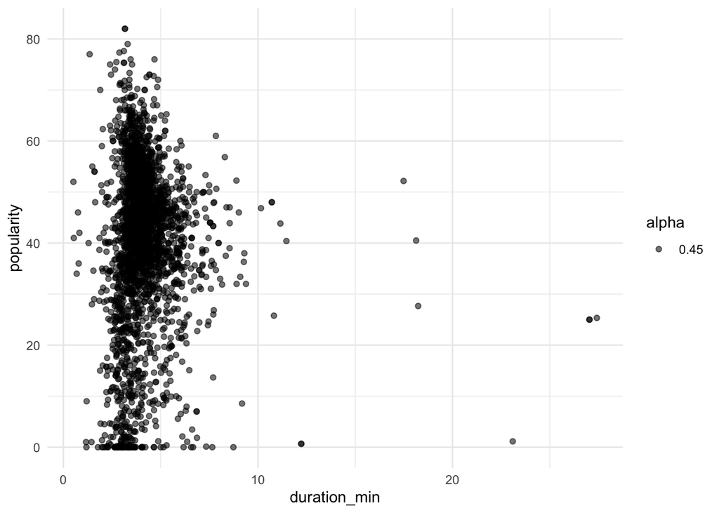

```r
durVpop <- ggplot(data = genres, aes(x = duration_min, y = popularity, alpha = .45)) +
  geom_point() +
  theme_minimal()

durVpop
```

- This graph is not useful; there are a lot of songs around the 2-5 minute range that are clogging this graph up significantly, and its hard to identify any meaningful relationship.

### Punk v Non-Punk Visuals

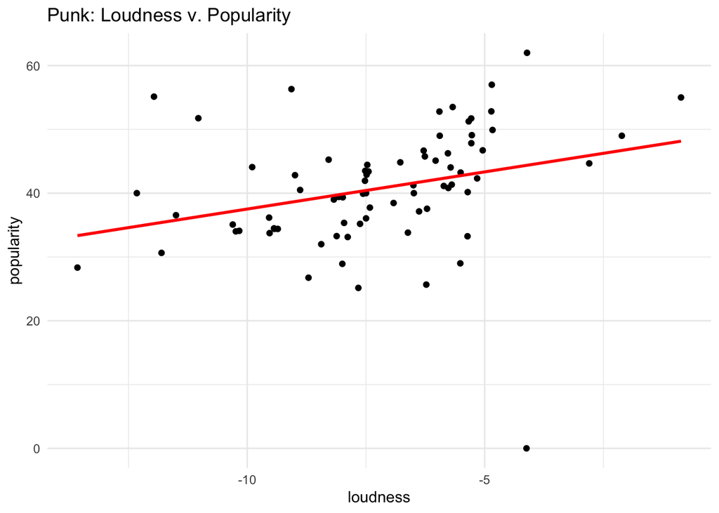

```r
punkLoudPop <- ggplot(data = punk, aes(x = loudness, y = popularity)) +
  geom_point() +
  geom_smooth(method='lm', color = 'red', se = F) +
  theme_minimal() +
  labs(title = 'Punk: Loudness v. Popularity')

punkLoudPop
```

- As we might have expected, there is a general positive relationship between loudness and popularity.

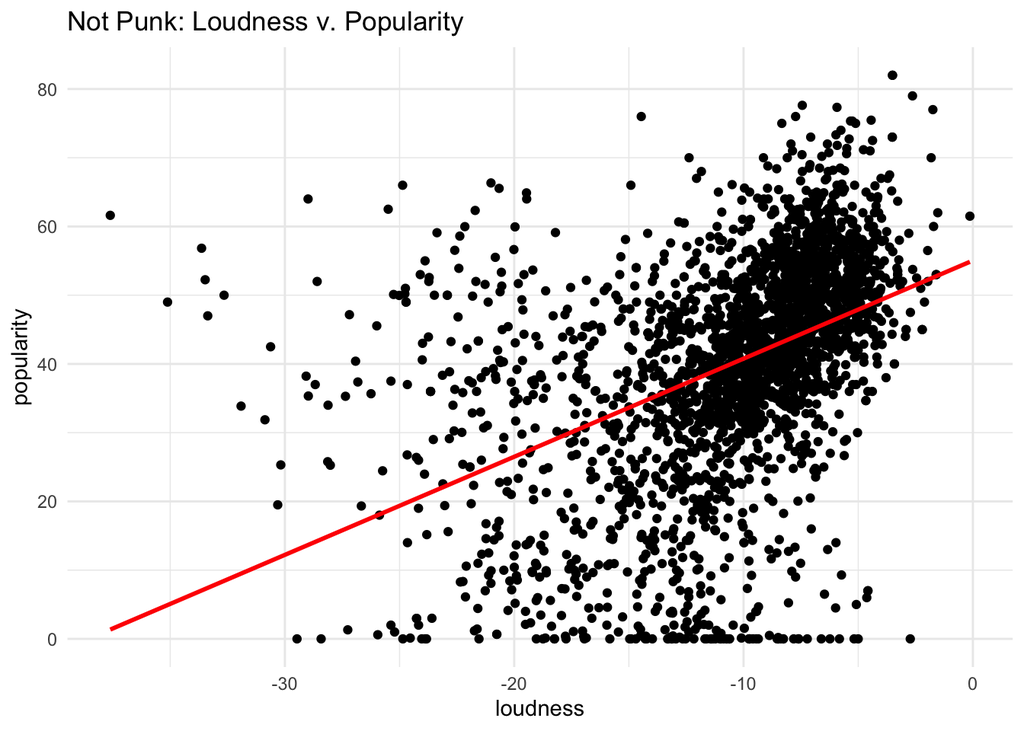

```r
notpunkLoudPop <- ggplot(data = not_punk, aes(x = loudness, y = popularity)) +
  geom_point() +
  geom_smooth(method='lm', color = 'red', se = F) +
  theme_minimal() +
  labs(title = 'Not Punk: Loudness v. Popularity')

notpunkLoudPop
```

- This is certainly interesting, as the loudness vs popularity relationship in non-punk music seems much stronger than the punk relationship we visualized in the last figure. May be significant, may be due to number of observations.

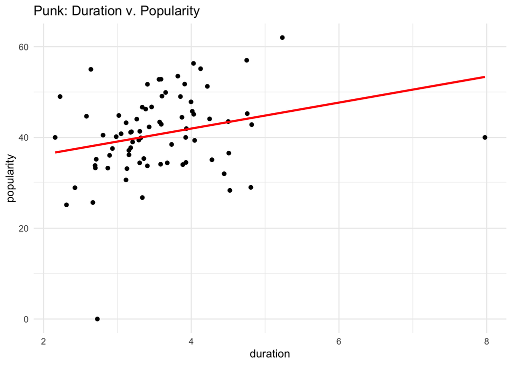

```r
punkDurPop <- ggplot(data = punk, aes(x = duration, y = popularity)) +
  geom_point() +
  geom_smooth(method='lm', color = 'red', se = F) +
  theme_minimal() +
  labs(title = 'Punk: Duration v. Popularity')

punkDurPop
```

- Duration has a slight positive relationship with popularity in punk music? Which seems… off. The number of observations here may be cause for concern, particularly some of those outlines at the top there.

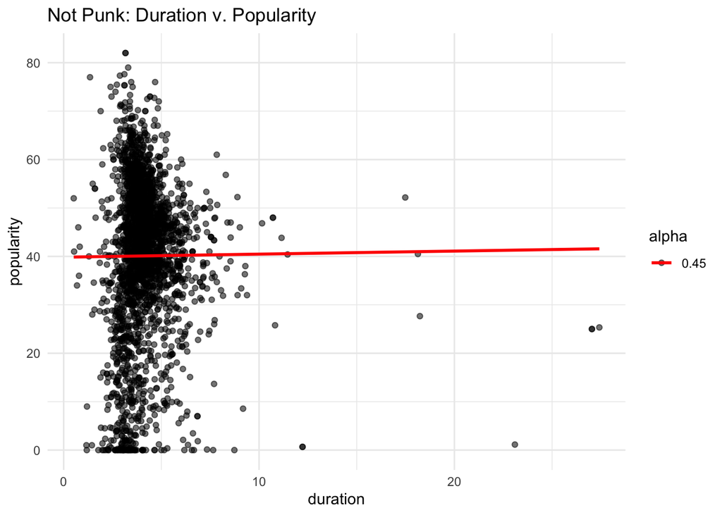

```r
notpunkDurPop <- ggplot(data = not_punk, aes(x = duration, y = popularity, alpha = .45)) +
  geom_point() +
  geom_smooth(method='lm', color = 'red', se = F) +
  theme_minimal() +
  labs(title = 'Not Punk: Duration v. Popularity')

notpunkDurPop
```

- As one might expect, there is essentially no relationship between duration and popularity in the rest of music (non-punk).